# Kommt es auf die Lehrkraft an?

## Überblick: Kommt es auf die Lehrkraft an?

- Aktivierung Ihres Vorwissens
  - Was verbinden Sie mit dem Begriff »Unterrichtsqualität«?
  - Ihre Meinung: Kommt es auf die Lehrkraft an?
- Definition & Verortung: »Unterrichtsqualität«
- Kommt es auf die Lehrkraft an?
  - »Besondere« Forschungsdesigns
  - Befunde
- Zusammenfassung

Alle Folien & deren Quellcode unter https://bit.ly/merk010 verfügbar

## Aktivierung Ihres Vorwissens

## Zunächst *Ihre Auffassung/Ihr Vorwissen/Ihre Meinung:*

[interactive chart not shown]

Alle Folien & deren Quellcode unter https://bit.ly/merk010 verfügbar

## Verortung & Definition

## Unterrichtsqualität

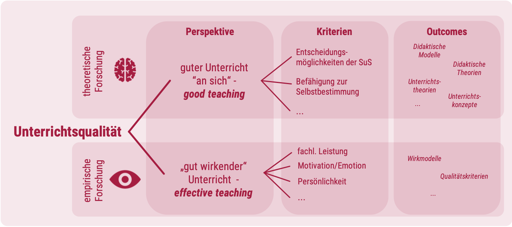

Abb. 1: Überblick Unterrichtsqualitätsforschung. Eigene Darstellung nach einer Idee von Berliner (2005)

Alle Folien & deren Quellcode unter https://bit.ly/merk010 verfügbar

## Unterrichtsqualität: Definition & Kontext

**Eine vglw. breite Definition nach Klieme (2019, S. 396):**  
*»Unterrichtsqualität wird hier also verstanden als Gesamtheit der empirisch beobachtbaren Merkmale des Unterrichtsgeschehens, die nachweislich mit der Entwicklung der Lernenden im Sinne der Realisierung von Bildungs- und Erziehungszielen einhergehen.«*

Im Kontext aktueller empirischer (insb. deutschsprachiger) Forschung

- wird meistens die Leistungsentwicklung als Kriterium fokussiert (Kunter et al., 2013);
- werden meistens sog. generische Tiefenstrukturen als Unterrichtsmerkmale betrachtet (Praetorius et al., 2018)
  - Klassenführung (classroom management)
  - Konstruktive Unterstützung (student support)
  - Kognitive Aktivierung (cognitive activation)

## Kurze Übung

## Übung 1

[interactive chart not shown]

## Übung 2

[interactive chart not shown]

## Übung 3

[interactive chart not shown]

## Kommt es auf die Lehrkraft an?

## Kommt es auf die Lehrkraft an?

### Häufige, aber »schwache« Forschungsdesigns

- Querschnittliche Stichproben
- Querschnittliche »Klumpenstichproben«
- Längsschnittliche »Klumpenstichproben«

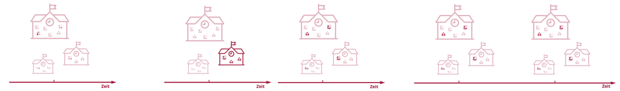

Abb. 3: Forschungsdesigns

## Häufige Designs: Querschnittliche Stichproben

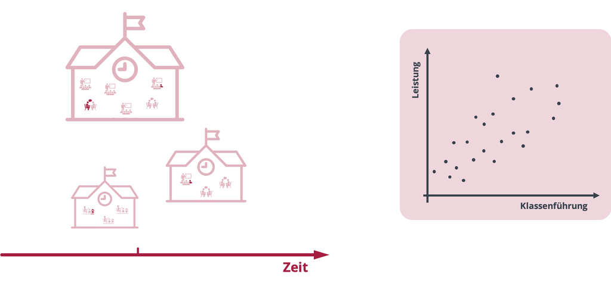

Abb. 4: Querschnittliche Stichprobe

## Häufige Designs: Querschnittliche Klumpenstichproben

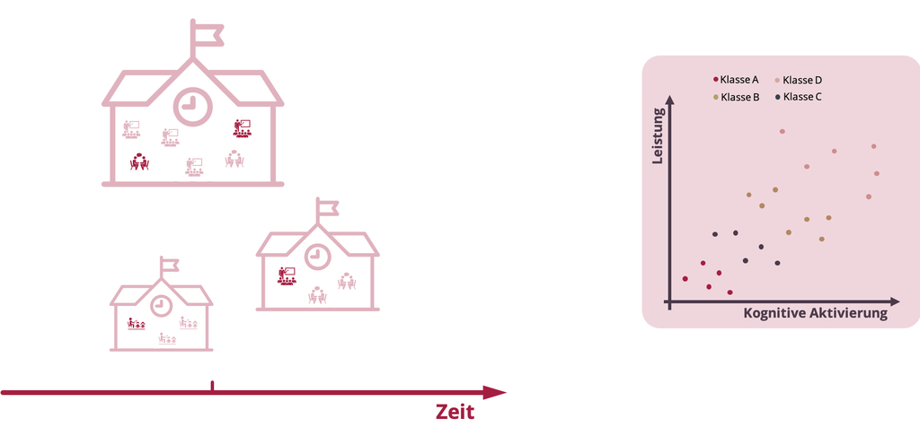

## Häufige Designs: Längsschnittliche Klumpenstichproben

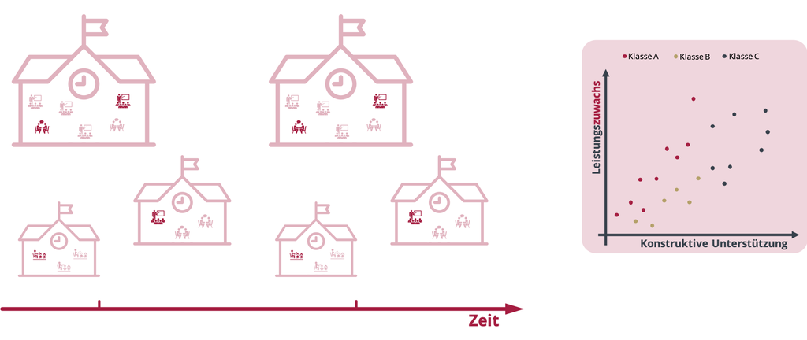

Abb. 6: Längsschnittliche Klumpenstichprobe

## Kommt es auf die Lehrkraft an?

### Häufige, aber »schwache« Forschungsdesigns

- Querschnittliche Stichproben
- Querschnittliche »Klumpenstichproben«
- Längsschnittliche »Klumpenstichproben«

\(\Rightarrow\) wenig informativ zur Beantwortung der Frage »Kommt es auf die Lehrkraft an?«

## Kommt es auf die Lehrkraft an?

### Seltene Forschungsdesigns

- Intensive Daten (z.B. Fauth et al., 2021; Meissner et al., 2020)
  - *Dieselbe Lehrerin unterrichtet dasselbe in verschiedenen Klassen*
- Imperfekte Hierarchien (z.B. Meissner et al., 2016; Merk et al., 2019; Praetorius et al., 2016)
  - *Beobachtung von vielen Lehrer*innen in ihren diversen Klassen*
- Randomisierte imperfekte Hierarchien (Lei et al., 2018; z.B. Polikoff, 2015)
  - *Lehrer*innen werden beobachtet und danach anderen Klassen zufallsbasiert zugeordnet*

\(\Rightarrow\) informativer zur Beantwortung der Frage »Kommt es auf die Lehrkraft an?«

## Exemplarische Befunde

## Exemplarische Befunde: Intensive Daten

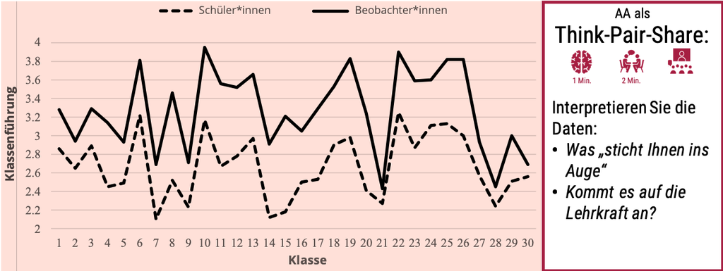

Abb. 2: Mehrfach beobachtete Unterrichtsqualität einer Lehrkraft (Fauth et al., 2021)

[interactive chart not shown]

## Exemplarische Befunde: Imperfekte Hierarchie

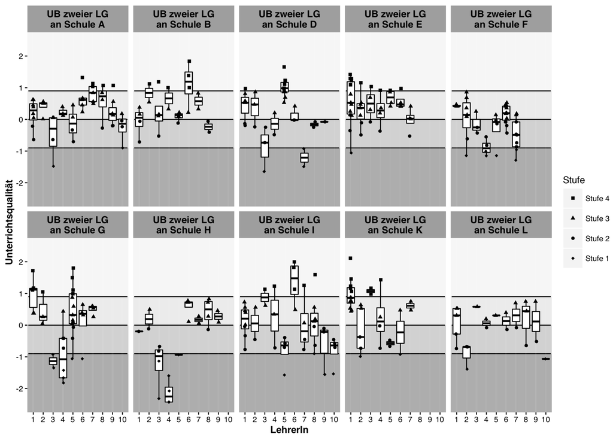

Abb. 3: Mehrfach beobachtete Unterrichtsqualität mehrerer Lehrkräfte (Meissner et al., 2016)

## Kommt es auf die Lehrkraft an?

### Exemplarische Befunde: Randomisierte imperfekte Hierarchie

- Lehrerspezifische Leistungszuwächse (Teacher Added Values; TAV) korrelieren von Jahr zu Jahr nur schwach
- Kumulierte TAV prädizieren neue TAV wesentlich besser (Polikoff, 2015)
- Unterrichtsqualität prädiziert Added Values
  - in Klassen in welcher sie erhoben wurde »moderat«
  - in einer zukünftigen Klasse »nur schwach« (Raudenbush & Jean, 2014)

## Zusammenfassung

## Zusammenfassung

- »Guter Unterricht« meistens **definiert** als Orchestrierung von »good teaching« (Inhalte, Methoden) und »effective teaching«
- »Unterrichtsqualität« meistens **operationalisiert** als mehrdimensionale Tiefenstrukturen
- Kommt es auf die Lehrkraft an?
  - Frage nur in »starken Designs« beantwortbar
  - Eine Antwort:
    - Unterrichtsqualität i.S. eines »effective teaching« ist eine Ko-Konstruktion von Schüler*innen und Lehrer*innen  
      *\(\Rightarrow\) Weiterentwicklung von Unterrichtsqualität ebenfalls eine Ko-Konstruktive Aufgabe*

## Herzlichen Dank für Ihre Aufmerksamkeit!

## Literatur

Berliner, D. C. (2005). The near impossibility of testing for teacher quality. *Journal of Teacher Education*, *56*(3), 205–213. https://doi.org/10.1177/0022487105275904

Fauth, B., Atlay, C., Dumont, H., & Decristan, J. (2021). Does what you get depend on who you are with? Effects of student composition on teaching quality. *Learning and Instruction*, *71*, 101355. https://doi.org/10.1016/j.learninstruc.2020.101355

Klieme, E. (2019). Unterrichtsqualität. In M. Harring, C. Rohlfs, & M. Gläser-Zikuda (Eds.), *Handbuch Schulpädagogik* (pp. 393–408). Waxmann.

Kunter, M., Klusmann, U., Baumert, J., Richter, D., Voss, T., & Hachfeld, A. (2013). Professional competence of teachers: Effects on instructional quality and student development. *Journal of Educational Psychology*, *105*(3), 805–820. https://doi.org/10.1037/a0032583

Lei, X., Li, H., & Leroux, A. J. (2018). Does a teacher’s classroom observation rating vary across multiple classrooms? *Educational Assessment, Evaluation and Accountability*, *30*(1), 27–46. https://doi.org/10.1007/s11092-017-9269-x

Meissner, S., Merk, S., Fauth, B., & Bohl, T. (2020). Differenzielle Effekte der Unterrichtsqualität auf die aktive Lernzeit. *Zeitschrift Für Pädagogik*, *66*(1), 81–94.

Meissner, S., Merk, S., Pietsch, M., & Bohl, T. (2016). Unterrichtsqualität an Gemeinschaftsschulen. Ergebnisse quantitativer und qualitativer Untersuchungen zur Qualität unterrichtlicher Prozesse an ausgewählten Gemeinschaftsschulen. In T. Bohl & A. Wacker (Eds.), *Die Einführung der Gemeinschaftsschule in Baden- Württemberg* (pp. 192–211). Waxmann.

Merk, S., Meissner, S., & Bohl, T. (2019). Intra- und interindividuelle Variabilität der aktiven Lernzeit von Schülerinnen und Schülern. *Gesellschaft Für Empirische Bildungsforschung*.

Polikoff, M. S. (2015). The stability of observational and student survey measures of teaching effectiveness. *American Journal of Education*, *121*(2), 183–212. https://doi.org/10.1086/679390

Praetorius, A. K., Klieme, E., Herbert, B., & Pinger, P. (2018). Generic dimensions of teaching quality: The German framework of three basic dimensions. *Mathematics Education*, *50*(3), 407–426. https://doi.org/10.1007/s11858-018-0918-4

Praetorius, A.-K., Vieluf, S., Saß, S., Bernholt, A., & Klieme, E. (2016). The same in German as in English? Investigating the subject-specificity of teaching quality. *Zeitschrift Fur Erziehungswissenschaft*, *19*, 191–209. https://doi.org/10.1007/s11618-015-0660-4

Raudenbush, S. W., & Jean, M. (2014). To what extend do student perceptions of classroom quality predict teacher value added? In T. J. Kane, K. A. Kerr, & R. C. Pianta (Eds.), *Designing Teacher Evaluation Systems* (pp. 170–202). Jossey-Bass.